# 基金重仓股票自动化报告

大数据驱动投资

QuandlFinance

2019-10-29

[figure not shown]

# 投资背景

资管新规以后,固收类产品打破刚性兑付,收益持续下降,权益类资产迎来黄金发展周期.权益类基金作为资产配置.基金投资与股票投资相辅相成. 更多内容关注**QuandlFinance**微信公众号.`资讯产品`相关资讯服务.若对**基金投资**不了解的,更多内容参见 @QuandlFinance。

QuandlFinance好基工作室和 每日金股池

# 白酒板块

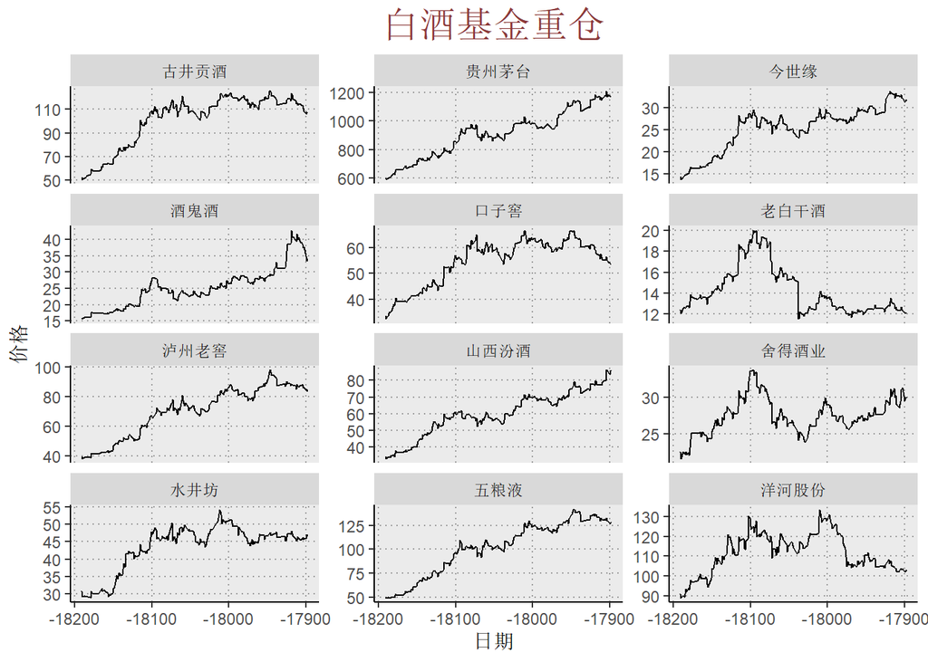

# 医药健康板块

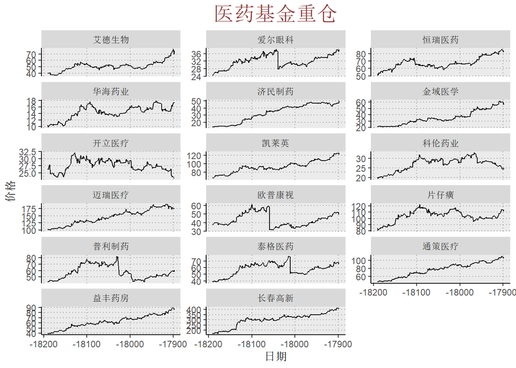

# 房地产板块

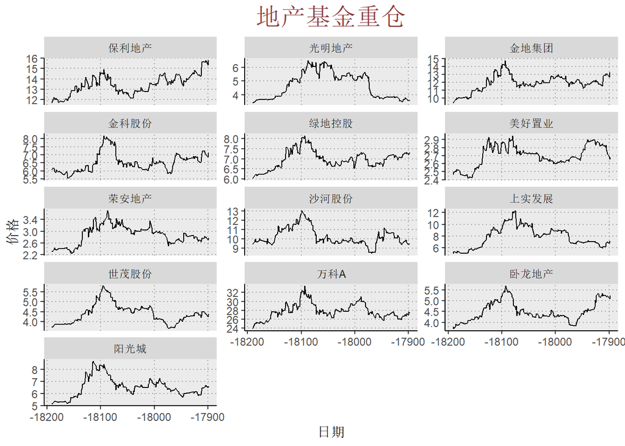

# 电器消费板块

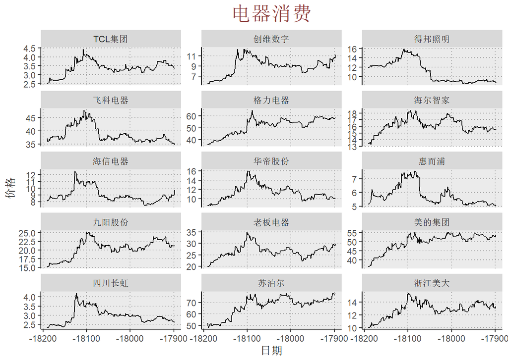

# 啤酒板块

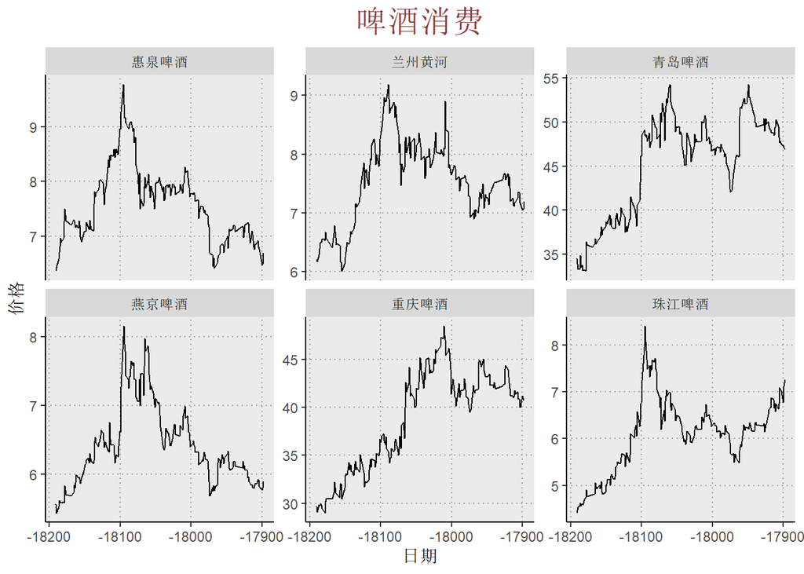

# 食品消费板块

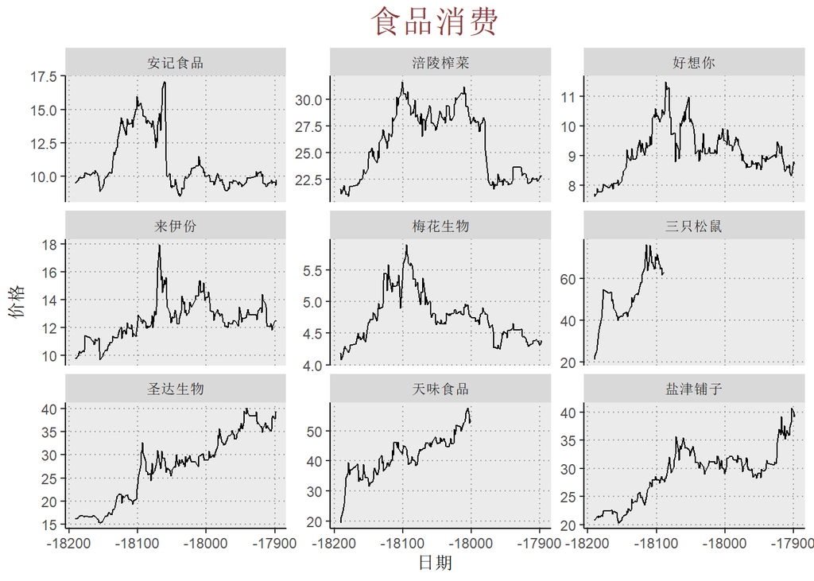

# 肉类食品

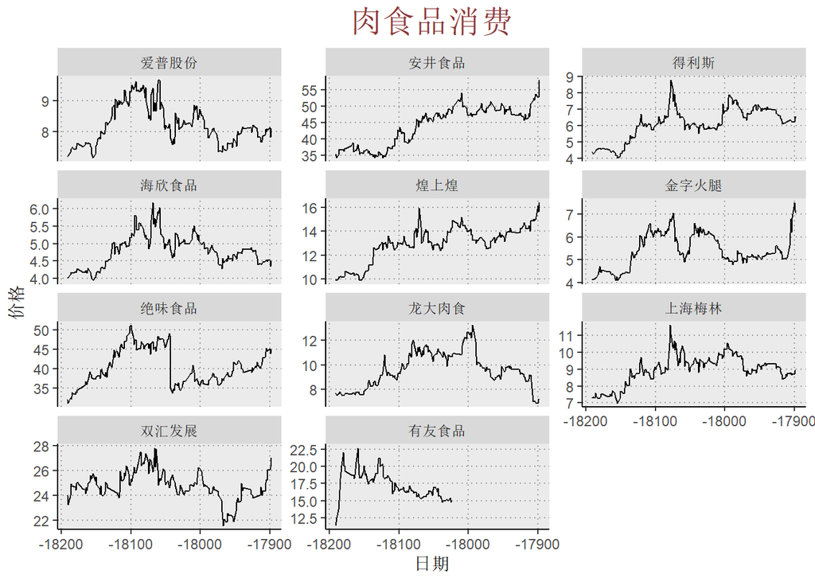

```
风险最大时,也是机遇最大时.别人恐惧时,我们要贪婪！！
```

# 本周投资策略

> 以改革促降息，科技股积极可为 内外部环境仍相对温和，积极信号进一步增多，结构性机会积极可为：外部环境看，美国期限利差倒挂预示美国经济下行压力和美国波动压力，对A股影响有限。内部环境看，LPR机制形成，以利率市场化改革方式促降息，有望引导实体经济融资成本下行，叠加减税降费等政策效果的逐步显现，企业成本费用端压力有望进一步降低，市场风险偏好有望改善；8月以来，国内长端利率明显下行，创2017年以来新低。配置上，继续推荐科技股+汽车，优选华为产业链+半导体产业链。

# 投资大师的成功法则

大师最初也是初学者,跟随大师的脚步才能快速成长.

> “集中投资就是计划生育:股票越少，组合业绩越好;长期持有就是龟兔赛跑:长期内复利可以战胜一切;”

# 投资建议

> 1 采用金字塔式投资策略,震荡的行情中按比例1:2:3:4分布建仓！

> 2 延长持有周期,追求一定周期内的绝对投资回报！

> 3 投资有风险,投资需谨慎！！